# Intro

## Step 3: Just throw XGBOOST at it!

XGBOOST is the black-box algorithm that dominates at the top tiers of data science competitions on Kaggle. Let's see how it does with some random parameters. Since boosting will choose the trees that do well, we don't need to worry about narrowing down our features list like before.

```python
print('splitting dataset into training and test data...')
train_ids, valid_ids, test_ids, xdata, xvalid, xtest, ydata, yvalid, ytest = \
    split_dset_with_valid(df, selected_feat, 'Responder_Flg', _seed)

print('running xgboost')
# Set our parameters for xgboost
params = {}
params['objective'] = 'binary:logistic'
params['eval_metric'] = 'logloss'
params['eta'] = 0.02
params['max_depth'] = 4

d_train = xgb.DMatrix(xdata, label=ydata)
d_valid = xgb.DMatrix(xvalid, label=yvalid)

watchlist = [(d_train, 'train'), (d_valid, 'valid')]

bst = xgb.train(params, d_train, 400, watchlist, early_stopping_rounds=50, verbose_eval=10)
```

[output not shown]

```
evaluating model...
Train per-mail-value: $44.30
Validation per-mail-value: $17.56
Test per-mail-value: $18.88
RR: 0.1536
```

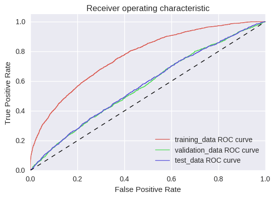

```python
d_test = xgb.DMatrix(xtest)
train_prob = bst.predict(d_train)
valid_prob = bst.predict(d_valid)
test_prob = bst.predict(d_test)

train_output = pd.DataFrame({'id':train_ids, 'probability':train_prob})
valid_output = pd.DataFrame({'id':valid_ids, 'probability':valid_prob})
test_output = pd.DataFrame({'id':test_ids, 'probability':test_prob})
# evaluate
print('evaluating model...')
train_cash = per_mailing_revenue(train_output)
valid_cash = per_mailing_revenue(valid_output)
test_cash = per_mailing_revenue(test_output)
print('Train per-mail-value: ${0:0.2f}'.format(train_cash))
print('Validation per-mail-value: ${0:0.2f}'.format(valid_cash))
print('Test per-mail-value: ${0:0.2f}'.format(test_cash))
print('RR: {:0.4f}'.format(get_response_rate(test_output)))
plot_ROC([('training_data', ydata, train_prob), ('validation_data', yvalid, valid_prob), ('test_data', ytest, test_prob)])
```

# Step 4: Optimize the hyperparameters

We need to tune the approach to maximize our performance. We will do this via hyperparameter optimization! The gp_optimize routine approximates the function mapping hyperparameters to performance as a Gaussian Process and makes Bayesian high-likelihood informed guesses about what hyperparameters to try next. This step may actually not have done much overall, since the performance function is calculated over a very small sample of responders in the test set and is thus pretty noisy.

```python
# trying out skopt with scikit gb trees
features = selected_feat
train_ids, valid_ids, test_ids, xdata, xvalid, xtest, ydata, yvalid, ytest = \
        split_dset_with_valid(df, features, 'Responder_Flg', _seed)

def objective(params):
    # time this part
    start = time.time()

    gamma, alpha, lamb, min_child_weight, max_depth, subsample, colsample_bytree, iterations = params
    # Set our parameters for xgboost
    params = {}
    # these are constant
    params['objective'] = 'binary:logistic'
    params['eval_metric'] = 'logloss'
    params['eta'] = 0.02
    # these are tuned
    params['gamma'] = gamma
    params['alpha'] = alpha
    params['lambda'] = lamb
    params['min_child_weight'] = min_child_weight
    params['max_depth'] = max_depth
    params['subsample'] = subsample
    params['colsample_bytree'] = colsample_bytree

    d_train = xgb.DMatrix(xdata, label=ydata)
    d_valid = xgb.DMatrix(xvalid, label=yvalid)

    bst = xgb.train(params, d_train, iterations)

    valid_prob = bst.predict(d_valid)
    valid_output = pd.DataFrame({'id':valid_ids, 'probability':valid_prob})
    valid_cash = per_mailing_revenue(valid_output)

    # timing
    end = time.time()
    print('Iteration completed in {:.1f} seconds with validation return: ${:.3f}'.format(end - start, valid_cash))
    return -valid_cash

space  = [(0.0, 0.5),               # gamma
          (0.0, 1.0),               # alpha
          (0.0, 1.0),               # lambda
          (1, 5),                   # min_child_weight
          (2, 6),                   # max_depth
          (.6, 1.0),                # subsample
          (.6, 1.0),                # colsample_bytree
          (200, 800),               # iterations
         ]
```

```python
from skopt import gp_minimize
# res_gp = gp_minimize(objective, space, n_calls=700, random_state=_seed)
# print('Best price achieved: ${:.3f}'.format(-res_gp.fun))
```

```
evaluating model...
Train per-mail-value: $60.70
Validation per-mail-value: $18.52
Test per-mail-value: $20.04
```

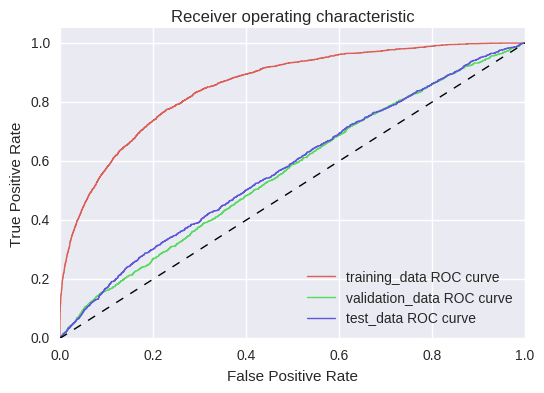

```python
# # get best params
# gamma, alpha, lamb, min_child_weight, max_depth, subsample, colsample_bytree, iterations = res_gp.x
# # Set our parameters for xgboost
# params = {}
# # these are constant
# params['objective'] = 'binary:logistic'
# params['eval_metric'] = 'logloss'
# params['eta'] = 0.02
# # these are tuned
# params['gamma'] = gamma
# params['alpha'] = alpha
# params['lambda'] = lamb
# params['min_child_weight'] = min_child_weight
# params['max_depth'] = max_depth
# params['subsample'] = subsample
# params['colsample_bytree'] = colsample_bytree

features = selected_feat
train_ids, valid_ids, test_ids, xdata, xvalid, xtest, ydata, yvalid, ytest = \
        split_dset_with_valid(df, features, 'Responder_Flg', _seed)
with open('optimal_params', 'rb') as fp:
    params = pickle.load(fp)
# print('optimized parameters are {} iterations and:'.format(iterations))
# print(params)

d_train = xgb.DMatrix(xdata, label=ydata)
d_valid = xgb.DMatrix(xvalid, label=yvalid)
d_test = xgb.DMatrix(xtest)

watchlist = [(d_train, 'train'), (d_valid, 'valid')]

# bst = xgb.train(params, d_train, 700, watchlist, early_stopping_rounds=25, verbose_eval=10)
bst = xgb.train(params, d_train, 570) # 570 was the optimal number of iterations, but was not stored in the pickle

train_prob = bst.predict(d_train)
valid_prob = bst.predict(d_valid)
test_prob = bst.predict(d_test)

train_output = pd.DataFrame({'id':train_ids, 'probability':train_prob})
valid_output = pd.DataFrame({'id':valid_ids, 'probability':valid_prob})
test_output = pd.DataFrame({'id':test_ids, 'probability':test_prob})
# evaluate
print('evaluating model...')
train_cash = per_mailing_revenue(train_output)
valid_cash = per_mailing_revenue(valid_output)
test_cash = per_mailing_revenue(test_output)
print('Train per-mail-value: ${0:0.2f}'.format(train_cash))
print('Validation per-mail-value: ${0:0.2f}'.format(valid_cash))
print('Test per-mail-value: ${0:0.2f}'.format(test_cash))
plot_ROC([('training_data', ydata, train_prob), ('validation_data', yvalid, valid_prob), ('test_data', ytest, test_prob)])
```

```python
print(get_response_rate(valid_output))
print(get_response_rate(test_output))
```

```
0.1512
0.1616
```

```python
payment = [lookup_dict[wid] for wid in test_output['id']]
test_output['payment'] = payment
# test_output.sort_values(by='probability', ascending=False)[:1200]
```

## Step 5: Use entire dataset to train, and make final predictions

We have identified a best-performing model (boosted trees with tuned hyperparameters), and so now it comes time to use the entire dataset to train the model and then to make predictions on the unlabeled dataset. With any luck this will be the winning entry!

```python
# prepare the datasets
unlab_df = pd.read_csv('../data/testing_data.csv')
unlab_df = unlab_df.set_index(df.W_ID)
unlab_df.columns = [c.strip() for c in unlab_df.columns.values]

# drop the column will all missing values
unlab_df = unlab_df.drop('colname',1)

# fill in missing values, replace missing continuous values with the average of the rows
unlab_df = unlab_df.replace(-1, np.nan)
cont_feats = unlab_df.select_dtypes(include=[np.number]).columns
unlab_df.loc[:,cont_feats] = unlab_df.loc[:,cont_feats].fillna(unlab_df.loc[:,cont_feats].mean())

for feature in unlab_df.columns: # Loop through all columns in the dataframe
    if unlab_df[feature].dtype.name == 'object': # Only apply for columns with categorical strings
        unlab_df[feature] = pd.Categorical(unlab_df[feature]).codes # Replace strings with an integer


target = 'Responder_Flg'
features = []
with open('rf_selected_features', 'rb') as fp:
    features = pickle.load(fp)

xtrain = df[features].as_matrix()
ytrain = colvec_to_array(df[[target]].as_matrix())
xtest = unlab_df[features].as_matrix()
train_ids = colvec_to_array(df['W_ID'].as_matrix())
test_ids = colvec_to_array(unlab_df['W_ID'].as_matrix())
```

```
evaluating model...
Train per-mail-value: $41.68
```

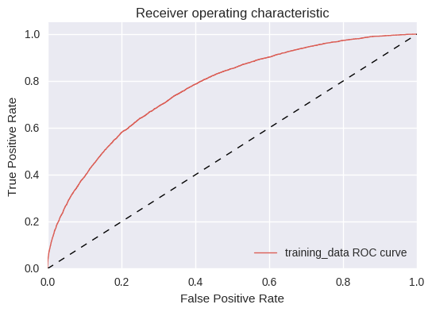

```
0.335
```

```python
d_train = xgb.DMatrix(xtrain, label=ytrain)
d_test = xgb.DMatrix(xtest)

params = {}
with open('optimal_params', 'rb') as fp:
    params = pickle.load(fp)

bst = xgb.train(params, d_train, 570)

train_prob = bst.predict(d_train)
test_prob = bst.predict(d_test)

train_output = pd.DataFrame({'id':train_ids, 'probability':train_prob})
test_output = pd.DataFrame({'id':test_ids, 'probability':test_prob})

# evaluate
print('evaluating model...')
train_cash = per_mailing_revenue(train_output)
print('Train per-mail-value: ${0:0.2f}'.format(train_cash))
plot_ROC([('training_data', ytrain, train_prob)])
print(get_response_rate(train_output))
```

```python
# results = test_output.sort_values(by='probability', ascending=False).reset_index(drop=True)
test_output.to_csv('predictions.csv', index=False)
```